# Modeling for Default

Modeling default for loan applications with various techniques

Author

Adam Bushman

Published

October 20, 2024

# Approach

I’m focusing on modeling for `DEFAULT` using Penalized Regression.

## Prep

Let’s load a few libraries:

```r
library('tidyverse')
library('glmnet')
library('caret')
library('pROC')
library('rsample')
```

We’ll load the cleaned, balanced, training data:

```r
path <- 'D:/All Repos/home-credit-default-risk-group/data/application_train_smote.csv'

data <- data.table::fread(path) |>
    as.data.frame()

glimpse(data)
```

```
Rows: 555,256
Columns: 181
$ CASH_LOAN.N                                       <dbl> 0, 0, 0, 0, 0, 0, 0,…
$ CASH_LOAN.Y                                       <dbl> 1, 1, 1, 1, 1, 1, 1,…
$ GENDER_MALE.N                                     <dbl> 0, 1, 1, 1, 0, 1, 1,…
$ GENDER_MALE.Y                                     <dbl> 1, 0, 0, 0, 1, 0, 0,…
$ FLAG_OWN_CAR.N                                    <dbl> 0, 0, 1, 1, 0, 1, 1,…
$ FLAG_OWN_CAR.Y                                    <dbl> 1, 1, 0, 0, 1, 0, 0,…
$ FLAG_OWN_REALTY.N                                 <dbl> 1, 0, 0, 0, 1, 1, 0,…
$ FLAG_OWN_REALTY.Y                                 <dbl> 0, 1, 1, 1, 0, 0, 1,…
$ CNT_CHILDREN                                      <dbl> 0, 1, 0, 0, 0, 1, 0,…
$ AMT_INCOME_TOTAL                                  <dbl> 90000, 252000, 31500…
$ AMT_CREDIT                                        <dbl> 263686.5, 675000.0, …
$ AMT_ANNUITY                                       <dbl> 19237.5, 53460.0, 52…
$ AMT_GOODS_PRICE                                   <dbl> 238500, 675000, 9000…
```

[output cut: 168 more lines]

We’ll work with a sample of the data since we have over 300K records.

```r
set.seed(814)

# Splits
split_obj <- initial_split(data)
full_train <- training(split_obj)
full_test <- testing(split_obj)

# 25% sample of the data
train_sampl <- sample_n(
    full_train, ceiling(nrow(full_train) * 0.25)
)

test_sampl <- sample_n(
    full_test, ceiling(nrow(full_test) * 0.25)
)
```

All features in this file may conceivably be helpful in predicting `DEFAULT` (originally named `TARGET`) so we shouldn’t need to subset any of them.

# Penalized Regression

## Prep

We have little to no way of knowing which will be predictive. Therefore, an elastic net is probably the best choice.

Let’s prepare the data for penalized regression. `glmnet` requires split predictors and target, with the latter being in a vector and the former being cast as a matrix.

```r
train_target <- train_sampl$DEFAULT
train_predictors <- as.matrix(
    train_sampl |> select(-DEFAULT)
)
```

We’ll also do it for the test sample data.

```r
test_target <- test_sampl$DEFAULT
test_predictors <- as.matrix(
    test_sampl |> select(-DEFAULT)
)
```

## Basic Modeling

Let’s run an elastic net model leveraging cross validation. We’ll use the default 10 folds. The output we get will measure `AUC` and the standard error thereof.

```r
mod1 <- cv.glmnet(
    x = train_predictors,
    y = train_target,
    family = "binomial",
    alpha = 0.5,
    type.measure = "auc"
)

mod1
```

```
Call:  cv.glmnet(x = train_predictors, y = train_target, type.measure = "auc",      family = "binomial", alpha = 0.5)

Measure: AUC

       Lambda Index Measure       SE Nonzero
min 0.0002293    78  0.7655 0.001077     166
1se 0.0023471    53  0.7646 0.001041     124
```

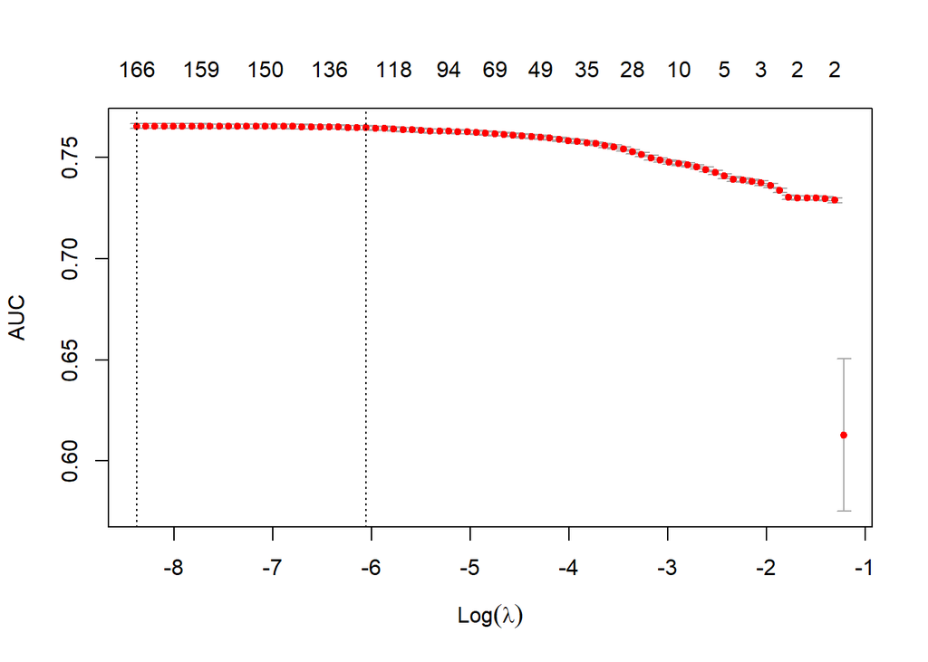

```r
plot(mod1)
```

Let’s look at the significant coefficients for the `1se` model since its VERY close to the absolute minimum in terms of performance:

```r
coef <- coef(mod1, "lambda.1se")
coef_df <- as.data.frame(as.matrix(coef))
coef_df$Predictor <- rownames(coef)
colnames(coef_df)[1] <- "Coefficient"
rownames(coef_df) <- NULL

coef_df |>
    select(Predictor, Coefficient) |>
    mutate(Important_Flag = ifelse(Coefficient == 0, 0, 1)) |>
    arrange(desc(abs(Coefficient)))
```

```
                                            Predictor   Coefficient
1                                         (Intercept)  3.532973e+00
2                                        EXT_SOURCE_3 -3.328217e+00
3                                        EXT_SOURCE_2 -2.440205e+00
4                         NAME_INCOME_TYPE.Unemployed  1.700417e+00
5                                        EXT_SOURCE_1 -1.580913e+00
6                            NAME_INCOME_TYPE.Student -1.050433e+00
7                           ORGANIZATION_TYPE.Realtor  9.793680e-01
8                 NAME_EDUCATION_TYPE.Academic.degree -9.391707e-01
9                  ORGANIZATION_TYPE.Industry..type.5 -5.920880e-01
10                ORGANIZATION_TYPE.Transport..type.3  5.838330e-01
11                   ORGANIZATION_TYPE.Legal.Services  5.360799e-01
12                 OCCUPATION_TYPE.Low.skill.Laborers  4.543564e-01
13                         ORGANIZATION_TYPE.Military -4.502721e-01
14                    NAME_TYPE_SUITE.Group.of.people  4.337982e-01
```

[output cut: 349 more lines]

The external source variables are highly important and predictive.

## Saving model results

Let’s use the model we found to be the best and predict new probabilities of the classification.

```r
pred_probs <- predict(mod1, newx = test_predictors, s = 'lambda.1se', type = 'response')
```

Now, we need to find the ideal threshold for classification of the probabilities:

```r
roc_obj <- roc(ifelse(test_target == "Y", 1, 0), pred_probs)
youden_index <- roc_obj$sensitivities + roc_obj$specificities - 1

optimal_index <- which.max(youden_index)
optimal_threshold <- roc_obj$thresholds[optimal_index]
optimal_threshold
```

```
[1] 0.4280494
```

We can now use this optimal threshold for the confusion matrix:

```r
mat1 <- confusionMatrix(
    factor(ifelse(pred_probs > optimal_threshold, 1, 0), levels = c(1,0)),
    factor(ifelse(test_target == "Y", 1, 0), levels = c(1,0))
)

mat1
```

```
Confusion Matrix and Statistics

          Reference
Prediction     1     0
         1 13538  6981
         0  3526 10659

               Accuracy : 0.6972
                 95% CI : (0.6924, 0.7021)
    No Information Rate : 0.5083
    P-Value [Acc > NIR] : < 2.2e-16

                  Kappa : 0.3963

 Mcnemar's Test P-Value : < 2.2e-16

            Sensitivity : 0.7934
            Specificity : 0.6043
         Pos Pred Value : 0.6598
         Neg Pred Value : 0.7514
             Prevalence : 0.4917
         Detection Rate : 0.3901
   Detection Prevalence : 0.5913
      Balanced Accuracy : 0.6988

       'Positive' Class : 1
```

Let’s also grab the AUC value:

```r
auc1 <- auc(roc_obj)
auc1
```

```
Area under the curve: 0.762
```

Let’s compile all these metrics into a dataframe and save the results:

```r
performance <- c(
    c("model" = "Elastic Net"),
    c("hyperparameters" = paste(
        paste("Lambda:", mod1$lambda.1se),
        paste("Mix:", 0.5),
        paste("Cutoff:", optimal_threshold),
        collapse = ", "
    )),
    mat1$overall[c("Accuracy")],
    mat1$byClass[c("Precision", "Recall")],
    c("AUC" = auc1)
)

performance
```

```
                                                         model
                                                 "Elastic Net"
                                               hyperparameters
"Lambda: 0.002347112488074 Mix: 0.5 Cutoff: 0.428049365448963"
                                                      Accuracy
                                           "0.697239511295528"
                                                     Precision
                                           "0.659778741654077"
                                                        Recall
                                           "0.793366150961088"
                                                           AUC
                                           "0.761974812975667"
```

```r
data.frame(as.list(performance)) |>
    write.csv('models/penalized-regression/model-results.csv', row.names = FALSE)
```

## Tuned Modeling

The above, basic model assumes a perfect 50-50 elastic net. It could be, however, a better tuned model could improve performance. We test a few different values of `alpha` (the elastic net mix) to see if we can do any better. We will reduce the number of folds to help it run faster:

```r
mix <- seq(0.2, 0.8, 0.2)
results <- list()

for(m in mix) {
    t_mod <- cv.glmnet(
        x = train_predictors,
        y = train_target,
        family = "binomial",
        nfolds = 3,
        alpha = m,
        type.measure = "auc"
    )

    results[[length(results) + 1]] <- c(m, t_mod$cvm[t_mod$index])
}
```

```r
results_df <- as.data.frame(do.call(rbind, results))
names(results_df) <- c("mix", "AUC_lambda.min", "AUC_lambda.1se")
results_df
```

```
  mix AUC_lambda.min AUC_lambda.1se
1 0.2      0.7652886      0.7650394
2 0.4      0.7654275      0.7638517
3 0.6      0.7652099      0.7649984
4 0.8      0.7650149      0.7636397
```

We aren’t achieving really any better or worse results with a weighted elastic net. The next step would be determining if some interaction terms could improve things.

## Interaction terms

We’re going to create some interaction terms, something to indicate a varying relationship between predictors.

We’ll implement the following interactions, largely informed by data analysis work and what was found above to be important predictors in estimating default:

1. `CNT_CHILDREN` and `AMT_CREDIT`
2. `AMT_ANNUITY` and `AMT_CREDIT`
3. `DAYS_LAST_PHONE_CHANGE` and `AMT_REQ_CREDIT_BUREAU_DAY`
4. `REGION_RATING_CLIENT_W_CITY` and `DEF_30_CNT_SOCIAL_CIRCLE`
5. `AMT_REQ_CREDIT_BUREAU_DAY` and `AMT_CREDIT`
6. `AMT_CREDIT` and `AMT_GOODS_PRICE`
7. `EXT_SOURCE_#` and `IMPUTED_EXT#`

```r
add_interactions <- function(data) {
    alt_data <-
        data |>
        mutate(
            I_CHILDREN_X_CREDIT = CNT_CHILDREN * AMT_CREDIT,
            I_ANNUITY_X_CREDIT = AMT_ANNUITY * AMT_CREDIT,
            I_PHONE_CHANGE_X_CREDIT_BUREAU_DAY = DAYS_LAST_PHONE_CHANGE * AMT_REQ_CREDIT_BUREAU_DAY,
            I_REGION_RATING_X_30_SOCIAL = REGION_RATING_CLIENT_W_CITY * DEF_30_CNT_SOCIAL_CIRCLE,
            I_BUREAU_DAY_X_CREDIT = AMT_REQ_CREDIT_BUREAU_DAY * AMT_CREDIT,
            I_CREDIT_X_GOODS = AMT_CREDIT * AMT_GOODS_PRICE,
            I_EXT1_X_IMP1 = EXT_SOURCE_1 * IMPUTED_EXT1.Y,
            I_EXT2_X_IMP2 = EXT_SOURCE_2 * IMPUTED_EXT2.Y,
            I_EXT3_X_IMP3 = EXT_SOURCE_3 * IMPUTED_EXT3.Y
        )
    return(alt_data)
}

alt_train_sampl <- add_interactions(train_sampl)
alt_test_sampl <- add_interactions(test_sampl)
```

```r
alt_train_predictors <- as.matrix(
    alt_train_sampl[,-which(names(alt_train_sampl) %in% c("DEFAULT"))]
)
```

Let’s now use the interaction variables in another cross validated model:

```r
mod2 <- cv.glmnet(
    x = alt_train_predictors,
    y = train_target,
    family = "binomial",
    alpha = 0.5,
    type.measure = "auc"
)

mod2
```

```
Call:  cv.glmnet(x = alt_train_predictors, y = train_target, type.measure = "auc",      family = "binomial", alpha = 0.5)

Measure: AUC

       Lambda Index Measure       SE Nonzero
min 0.0001196    85  0.7834 0.001855     176
1se 0.0004398    71  0.7817 0.001859     165
```

Let’s see if any of these interactions show up as important predictors:

```r
coef <- coef(mod2, "lambda.1se")
coef_df <- as.data.frame(as.matrix(coef))
coef_df$Predictor <- rownames(coef)
colnames(coef_df)[1] <- "Coefficient"
rownames(coef_df) <- NULL

coef_df |>
    select(Predictor, Coefficient) |>
    mutate(Important_Flag = ifelse(Coefficient == 0, 0, 1)) |>
    arrange(desc(abs(Coefficient)))
```

```
                                            Predictor   Coefficient
1                                       I_EXT3_X_IMP3 -1.528889e+01
2                                         (Intercept)  1.375993e+01
3                                       I_EXT1_X_IMP1 -1.110790e+01
4                                       I_EXT2_X_IMP2 -8.576275e+00
5                                      IMPUTED_EXT3.N -4.591983e+00
6                                      IMPUTED_EXT3.Y  3.704059e+00
7                                      IMPUTED_EXT2.N -3.624469e+00
8                                      IMPUTED_EXT1.N -3.195336e+00
9                                        EXT_SOURCE_3 -3.055277e+00
10                           NAME_INCOME_TYPE.Student -2.792424e+00
11                                     IMPUTED_EXT1.Y  2.576911e+00
12                        NAME_INCOME_TYPE.Unemployed  2.412100e+00
13                                       EXT_SOURCE_2 -2.399968e+00
14                                     IMPUTED_EXT2.Y  1.600262e+00
```

[output cut: 367 more lines]

- The interactions between external source and their imputed flags are very high; we’d expect to see this and its important they do so
- Others show up throughout but aren’t extremely notable

## Conclusion

There’s too many unique relationships to explore for an optimal model in the OLS family, even with the penalized regression flavor. We’re likely tapped-out with an AUC of **~0.76 - 0.78**.